# Conociendo la base de datos de la ENOE

# Introducción

El documento de INEGI(2023) permite:

- Conocer cómo se organiza la base de datos de la ENOE,
- Relacionar las tablas mediante las llaves únicas (primarias),
- Calcular el ponderador de subgrupos poblacionales,
- Utilizar los campos precodificados para obtener los indicadores estratégicos

Con el objetivo de facilitar el manejo de datos de la ENOE.

# 2. Conformación de la base de datos de la ENOE

La ENOE guarda su información en cinco tablas: * vivienda,  
* hogar,  
* sociodemográfico,  
* ocupación I y II

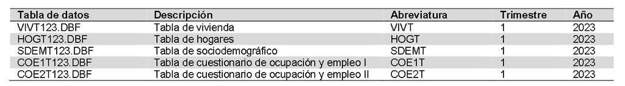

Fuente: INEGI(2023: 1).

Los nombres de las tablas, y en consecuencia de los archivos, se constituyen, por ejemplo, así:  
`SDEMT125.DBF`  
donde  
`SDEM` señala que pertenece a la sección Demográfica de la encuesta,  
`1` especifica que corresponde al primer trimestre y  
`25` que refiere al año 2025.

Desde el 2009 a la fecha, sólo en el trimestre I se utiliza el cuestion de ocupación y empleo (COE) ampliado; en los demás el cuestionario básico. Véase p. 2.

# 3. Registros

Desde el trimestre I de 2023 a la fecha, la ENOE tiene el siguiente número de campos en cada tabla:

| Tabla | Ampliado | Básico |
| --- | --- | --- |
| Vivienda | 25 | 25 |
| Hogares | 37 | 37 |
| Sociodemográfico | 110 | 114 |
| COE I | 189 | 172 |
| COE II | 137 | 82 |

Fuente: INEGI (2023)

Consulte INEGI(2024) para conocer la relación de los campos con cada pregunta de la ENOE.

# 4. La llave principal y su relación con cada tabla

La siguiente imagen muestra las llaves principales (*primary key*) de cada tabla:

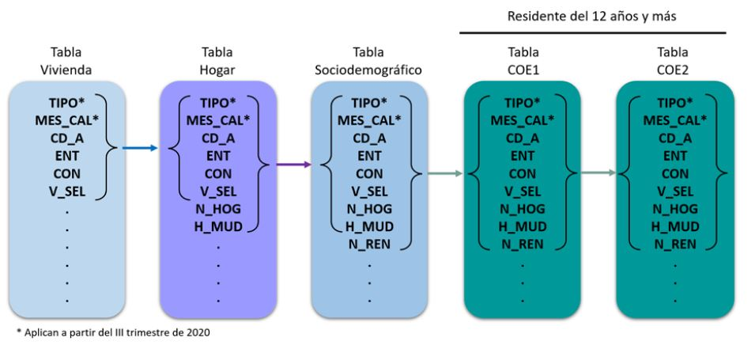

Fuente: INEGI(2023)

Relacionar la tabla sociodemográfico con la tabla COE (I y II)

1. Eliminar a los Ausentes definitivos (`2`) del campo Condición de residencia (`C_RES`).

```
# C_RES: condición de residencia
# 2: ausente definitivo
filter(C_RES != 2)
```

2. Conservar del campo `EDA` los códigos desde `12` hasta `98`, es decir, a personas con 12 años de edad hasta edad no especificada para mayores.

```
between(EDAD, 12, 98)
```

En otras palabras, se eliminan a las personas con condición de residencia de ausencia definitivo y menores a 12 años, incluso con edad no especificada, debido a que no existe registro de ellos en la tabla COE y sólo en la tabla Sociodemográfico.

# 5. Ponderaciones

¿Qué es el ponderador?

“El ponderador es el coeficiente que le otorga determinado peso en la muestra en función de su representatividad de otros tantos casos similares a él tomando en cuenta su estrato socioeconómico y lugar de residencia.” INEGI (2023: 9). Es decir, valor que indica cuántas personas de la población general están representadas en un único registro (observación). Por ejemplo, Contreras Cueva (2024) hace alusión al término pero con otro nombre: factor de expansión.

Desde el III trimestre de 2020, el ponderador trimestral se encuentra en las cinco tablas mediante el campo `FAC_TRIM` que “almacenan un valor numérico de 6 dígitos y este indica a cuántas personas representan de la población total.” INEGI(2023: 9).

¿Cómo unir las tablas de Sociodemográfica y de COE?

1. De la tabla Sociodemográfico, eliminar los valores distintos de `0` del campo asocioado al resultado definitivo de la entrevista `R_DEF`

```
# en la tabla SDEMT
filter(R_DEF == 0)
```

2. Suprimir los registros (observaciones) con condición de residencia ausente `C_RES == 2`

```
filter(C_RES != 2)
```

3. Eliminar a los menos de 12 años

```
between(EDA, 12, 98)
```

Después, se procede a realizar la unión mediante la llave principal. Ejemplo: véase p. 10

# 6. Principales variables de la ENOE

En la ENOE se aplica el cuestionario de ocupación y empleo solo a personas de 12 años y más a partir de lo establecido en la Ley Federal de Trabajo que señala la edad de 15 años como la edad mínima legal para trabajar.

La ENOE determina las siguientes variables y agrupaciones principales:

- Población total
  - Población menor de 15 años
  - Población de 15 años y más
    - Población económicamente activa (PEA)
      - Población ocupada
      - Población desocupada
    - Población no económicamente activa (PNEA)
      - Población disponible
      - Población no disponible

Para calcular las poblaciones de cualquier variable deben aplicarse ciertos criterios (filtros y condiciones). Consulte pp. 11-12 o el documento “Reconstrucción de variables de la ENOE” para ver los criterios se deben aplicarse a cada agrupación.

# 8. Precodificación

¿Qué son los campos precodificados?

“… son aquellos a los cuales se les asigna un valor, dependiendo del criterio de cada variable de los indicadores estratégicos o tabulados básicos…” INEGI (2023, p. 19). Es decir, son campos que no están asociados a alguna pregunta de la encuesta pero permiten identificar cada registro (observación) con cada variable o agrupación principal.

¿Dónde se localizan?

En la tabla Sociodemográfico y aparecen después el campo `FAC_TRI`, véase INEGI(2024, pp. 19-27) para ver la lista de todos los campos precodificados.

Cabe señalar que con los campos precodificados los criterios se simplifican como se observa en la p. 20

# 9. Indicadores estratégicos con campos precodificados

En esta sección se muestra un ejemplo de cómo obtener los indicadores estratégicos a partir de los campos precodificados con datos de la ENOE del cuarto trimestre de 2022. Se realizará dicho ejemplo al final de la sección.

Asimismo, se muestra los métodos de cálculo para obtener diversas como la tasa de participación (TP), la tasa de desocupación (TD), etc. desde la página 28 hasta 31.

Por otra parte, también se pueden calcular los indicadores estratégicos siguiendo ciertos criterios por:

- Ámbito (tamaño de la localidad): véase capítulo 10 p. 32
- Entidad o ciudad: véase capítulo 11 p. 33
- Tabulados básicos: véase capítulo 12 pp. 34-35

## Realización del ejemplo

Según INEGI(2023), los campos precodificados se encuentran en la tabla sociodemográfica por lo que sólo se trabajará con dicha tabla.

```r
library(tidyverse)
sdem <- read_csv(
  "enoet42022/ENOEN_SDEMT422.csv",
  col_types = cols(.default = col_character())
)
```

Se observa que la tabla sociodemográfica `sdem` está compuesta por 396629 filas y 114. De inicio, todos los valores de todas las columnas están de tipo caracter así que, en primer lugar, se segmentará únicamente la variable `FAC_TRIM` a tipo numérico.

```r
sdem <- sdem %>% mutate(
  fac_tri = as.double(fac_tri)
)
```

Ahora, procedemos a calcular los indicadores estratégicos.

1. Población total

```r
poblacion_total <- sdem %>% filter(
  r_def == "0",
  c_res != "2"
)

poblacion_total %>%
  summarise(
    sum(fac_tri)
  )
```

| sum(fac_tri) |
| --- |
| 128857600 |

2. Población de 15 años y más

| sum(fac_tri) |
| --- |
| 99515795 |

Cabe la pena destacar que el paso previo de segmentar la variable (columna) `eda` es la adecuada para obtener el dato que se observa en INEGI (2023, p. 21). En otras palabras, si se deja el tipo en caracter se obtendrá un resultado erróneo.

| sum(fac_tri) |
| --- |
| 114943551 |

¿Por qué el resultado es distinto si el tipo es numérico o caracter? Porque la función `between` ordena los valores en el tipo numérico y no ocurre lo mismo en el tipo caracter.

```r
poblacion_total %>%
  select(eda) %>%
  arrange(eda) %>%
  filter(between(eda, "15", "98"))
```

| eda |
| --- |
| 15 |
| 15 |
| 15 |
| 15 |
| 15 |
| 15 |
| 15 |
| 15 |
| 15 |
| 15 |

[output cut: 990 more lines]

```r
poblacion_total %>%
  transmute(
    eda = as.integer(eda)
  ) %>%
  filter(between(eda, 15, 98))
```

| eda |
| --- |
| 59 |
| 31 |
| 30 |
| 15 |
| 42 |
| 36 |
| 43 |
| 72 |
| 42 |
| 23 |

[output cut: 990 more lines]

No obstante, INEGI(2024, p. 16) señala que el campo `eda` es de tipo caracter y para que pueda obtenerse el mismo resultado con tal tipo de dato debe modificarse la condición en `filter`.

| sum(fac_tri) |
| --- |
| 99515795 |

| sum(fac_tri) |
| --- |
| 99515795 |

*Población económicamente activa (PEA) y Población no económicamente activa (PNEA)*

| clase1 | clase2 | sum(fac_tri) |
| --- | --- | --- |
| 1 | 1 | 58349353 |
| 1 | 2 | 1796103 |
| 2 | 3 | 5388751 |
| 2 | 4 | 33981588 |

*3.8 Condición de informalidad*

| emp_ppal | sum(fac_tri) |
| --- | --- |
| 1 | 32157340 |
| 2 | 26192013 |

## Resumen

Como se observa, los resultados coinciden con los mostrados en INEGI(2023, pp. 21-27).

# Referencias

INEGI (2023). Encuesta Nacional de Ocupación y Empleo (ENOE). Conociendo la base de datos de la ENOE https://www.inegi.org.mx/contenidos/programas/enoe/15ymas/doc/con_basedatos_proy2010.pdf

— (2024). Encuesta Nacional de Ocupación y Empleo (ENOE). Estructura de la base de datos https://www.inegi.org.mx/contenidos/programas/enoe/15ymas/doc/enoe_123_fd_c_bas_amp.pdf

Contreras Cueva, Angélica Beatriz. 2024. “Rendimiento y desajuste educativo de los trabajadores con educación superior en México. Un estudio diferenciado por género.” *Revista Vértice Universitario* 26 (95). https://doi.org/https://doi.org/10.36792/rvu.v26i95.108.